# **Entrega 2 - Proyecto Final APO 3**

### **Optimización de Hiperparámetros**

```python
# --- Random Forest ---
param_rf = {
    'n_estimators': [100, 200, 300],
    'max_depth': [5, 10, 15],
    'min_samples_split': [2, 5, 10]
}

grid_rf = GridSearchCV(RandomForestClassifier(random_state=42), param_rf, cv=3, n_jobs=-1, scoring='accuracy')
grid_rf.fit(X_train, y_train)
best_rf = grid_rf.best_estimator_
print(f"Mejor modelo Random Forest: {grid_rf.best_params_}")

# --- SVM ---
param_svm = {
    'C': [0.1, 1, 10],
    'gamma': ['scale', 0.01, 0.001],
    'kernel': ['rbf']
}

grid_svm = GridSearchCV(SVC(random_state=42), param_svm, cv=3, n_jobs=-1, scoring='accuracy')
grid_svm.fit(X_train, y_train)
best_svm = grid_svm.best_estimator_
print(f"Mejor modelo SVM: {grid_svm.best_params_}")

# --- XGBoost ---
param_xgb = {
    'n_estimators': [100, 200],
    'max_depth': [3, 5, 7],
    'learning_rate': [0.01, 0.1, 0.2],
    'subsample': [0.8, 1]
}

grid_xgb = GridSearchCV(
    XGBClassifier(eval_metric='mlogloss', random_state=42, num_class=len(np.unique(y_train))),
    param_xgb,
    cv=3,
    n_jobs=-1,
    scoring='accuracy'
)
grid_xgb.fit(X_train, y_train)
best_xgb = grid_xgb.best_estimator_
print(f"Mejor modelo XGBoost: {grid_xgb.best_params_}")
```

```
Mejor modelo Random Forest: {'max_depth': 5, 'min_samples_split': 2, 'n_estimators': 100}
Mejor modelo SVM: {'C': 1, 'gamma': 'scale', 'kernel': 'rbf'}
Mejor modelo XGBoost: {'learning_rate': 0.1, 'max_depth': 3, 'n_estimators': 100, 'subsample': 0.8}
```

### **Evaluación de modelos**

```
- Random Forest (Tuned)
                 precision    recall  f1-score   support

       Adelante       1.00      1.00      1.00         4
          Atras       1.00      1.00      1.00         4
Cadera_Alfrente       1.00      1.00      1.00         1
        Caderas       1.00      1.00      1.00         1
           Lado       1.00      1.00      1.00         1
     Sentadilla       1.00      1.00      1.00         2
        Sentado       1.00      1.00      1.00         4
        Tijeras       1.00      1.00      1.00         1

       accuracy                           1.00        18
      macro avg       1.00      1.00      1.00        18
   weighted avg       1.00      1.00      1.00        18
```

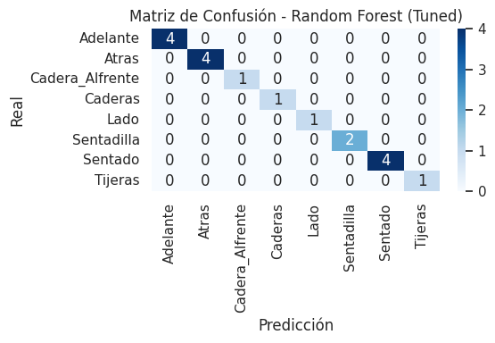

```
- SVM (Tuned)
                 precision    recall  f1-score   support

       Adelante       1.00      1.00      1.00         4
          Atras       1.00      1.00      1.00         4
Cadera_Alfrente       1.00      1.00      1.00         1
        Caderas       1.00      1.00      1.00         1
           Lado       1.00      1.00      1.00         1
     Sentadilla       1.00      1.00      1.00         2
        Sentado       1.00      1.00      1.00         4
        Tijeras       1.00      1.00      1.00         1

       accuracy                           1.00        18
      macro avg       1.00      1.00      1.00        18
   weighted avg       1.00      1.00      1.00        18
```

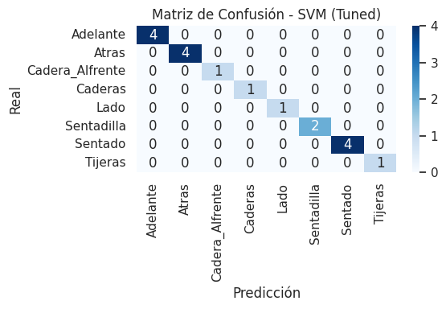

```
- XGBoost (Tuned)
                 precision    recall  f1-score   support

       Adelante       1.00      1.00      1.00         4
          Atras       1.00      1.00      1.00         4
Cadera_Alfrente       0.50      1.00      0.67         1
        Caderas       0.50      1.00      0.67         1
           Lado       1.00      1.00      1.00         1
     Sentadilla       0.00      0.00      0.00         2
        Sentado       1.00      1.00      1.00         4
        Tijeras       1.00      1.00      1.00         1

       accuracy                           0.89        18
      macro avg       0.75      0.88      0.79        18
   weighted avg       0.83      0.89      0.85        18
```

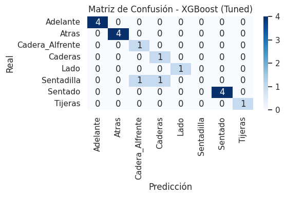

```python
# --- Entrenar modelos optimizados ---
modelos_opt = {
    "Random Forest (Tuned)": best_rf,
    "SVM (Tuned)": best_svm,
    "XGBoost (Tuned)": best_xgb
}

resultados = []

for nombre, modelo in modelos_opt.items():
    modelo.fit(X_train, y_train)
    y_pred = modelo.predict(X_test)
    acc = accuracy_score(y_test, y_pred)
    resultados.append({"Modelo": nombre, "Accuracy": acc})

    print(f"\n- {nombre}")
    print(classification_report(y_test, y_pred, target_names=label_encoder.classes_))

    cm = confusion_matrix(y_test, y_pred)
    plt.figure(figsize=(6,4))
    sns.heatmap(cm, annot=True, fmt="d", cmap="Blues",
                xticklabels=label_encoder.classes_,
                yticklabels=label_encoder.classes_)

    plt.title(f"Matriz de Confusión - {nombre}")
    plt.xlabel("Predicción")
    plt.ylabel("Real")
    plt.tight_layout()
    plt.show()
```

|  | Modelo | Accuracy |
| --- | --- | --- |
| 0 | Random Forest (Tuned) | 1.000000 |
| 1 | SVM (Tuned) | 1.000000 |
| 2 | XGBoost (Tuned) | 0.888889 |

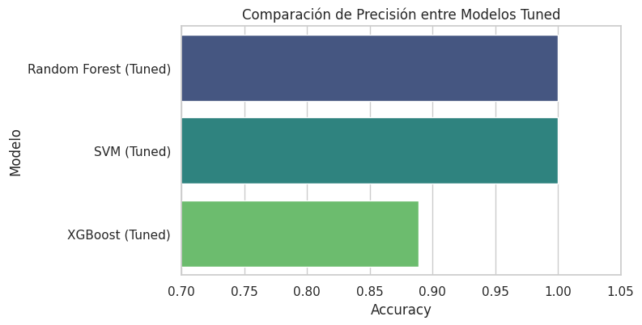

```python
# --- Comparación de métricas ---
df_resultados = pd.DataFrame(resultados).sort_values(by="Accuracy", ascending=False)
display(df_resultados)

plt.figure(figsize=(7, 4))
sns.barplot(x="Accuracy", y="Modelo", data=df_resultados, hue="Modelo", legend=False, palette="viridis")
plt.title("Comparación de Precisión entre Modelos Tuned")
plt.xlim(0.7, 1.05)
plt.show()
```

- **Interpretación de resultados**

El desempeño sobresaliente de **Random Forest** y **SVM** indica que las características extraídas del análisis de movimiento (como velocidad de cadera, ángulos articulares e inclinación de hombros) son **altamente discriminativas** entre las distintas posturas. Esto sugiere que el proceso de extracción de características mediante *MediaPipe Pose* y la posterior normalización fueron adecuados para capturar patrones biomecánicos relevantes.

Sin embargo, la precisión perfecta en ambos modelos también puede indicar **posible sobreajuste (overfitting)**, ya que el conjunto de datos aún es relativamente pequeño (86 observaciones totales, 8 clases). En contextos reales o con nuevos sujetos, es probable que el desempeño se reduzca.

El **modelo XGBoost**, aunque potente, requiere mayor cantidad de datos o un ajuste más fino para evitar la pérdida de precisión en clases minoritarias.